# Modelling inbreeding with care

```r
library(tidyverse)
library(stickylabeller) # labelling facets with strings in ggplot
library(rcartocolor) # for nice sequential colour schemes
library(ggtext)
library(patchwork)
```

## The framework

We can model whether inbreeding can invade an outbreeding population by counting the number of alleles that would be propagated by inbreeding individuals, compared to the number of alleles propagated if the individual were to instead outbreed. Let the average number of alleles propagated by an outbreeding female across her lifetime be $N_\mathrm{f}$, with the fraction $1/N_\mathrm{f}$ transmitted per effective mating. For an inbreeding female, the allele counting is more complex. Let the number of alleles transmitted to offspring produced as a result of a single inbreeding event be $(1 - \delta)$, where $\delta$ represents inbreeding depression. Investment in this mating and subsequent reproduction (e.g. through parental care) may affect future reproductive output; following Waser et al. (1986), let this cost be $\Delta N_\mathrm{f}$, such that future allele propagation is $N_\mathrm{f} - \Delta N_\mathrm{f}$. Finally, the number of allele copies indirectly propagated by the related male mating partner is $r(1 - \delta - \Delta N_\mathrm{m})$, where $r$ is the relatedness coefficient and $\Delta N_\mathrm{m}$ is the cost of male reproductive investment to his future allele propagation. $\Delta N_\mathrm{f}$ and $\Delta N_\mathrm{m}$ will generally range between zero and one, where zero indicates no cost to future mating success, while one represents complete replacement of an outcrossing event. Taken together, inbreeding is favoured for females when

$$(1 - \delta) + (N_\mathrm{f} - \Delta N_\mathrm{f}) + r(1 - \delta - \Delta N_\mathrm{m}) > N_\mathrm{f} \qquad \tag{1}$$

and for males when

$$(1 - \delta) + (N_\mathrm{m} - \Delta N_\mathrm{m}) + r(1 - \delta - \Delta N_\mathrm{f}) > N_\mathrm{m} \qquad \tag{2}$$

Equation 1 and Equation 2 can be rearranged to show that inbreeding is favoured by selection on females when:

$$\delta_\mathrm{f} < \frac{(1 -\Delta N_\mathrm{f}) + (r - r\Delta N_\mathrm{m})}{1 + r} \tag{3}$$

and on males

$$\delta_\mathrm{m} < \frac{(1 -\Delta N_\mathrm{m}) + (r - r\Delta N_\mathrm{f})}{1 + r}$$

If a round of reproduction following an inbred mating completely replaces the opportunity for an outbred round of reproduction in females ($\Delta N_\mathrm{f} = 1$), but has no effect on the future reproductive prospects of males ($\Delta N_\mathrm{f} = 0$) we recover $\delta_\mathrm{f} < \frac{r}{1 + r}$ and $\delta_\mathrm{m} < \frac{1}{1 + r}$, as previously found by Parker (1979).

## Adding an effect of care on $\delta$

If the costs to future reproduction $\Delta N_\mathrm{f}$ and $\Delta N_\mathrm{m}$ are primarily caused by investment in parental care, we can link this to the degree of inbreeding depression felt by offspring. For now, I assume that while care can affect the evolution of inbreeding preference, inbreeding does not influence the evolution of care. Let $c = (\Delta N_\mathrm{f} + \Delta N_\mathrm{m})/2$, the amount of care received by offspring, averaged across parents. We assume that $c$ affects reproductive output following an inbreeding event by moderating inbreeding depression, such that direct fitness is $1-\delta(1-\alpha c)$, where $\alpha$ controls the effectiveness of care.

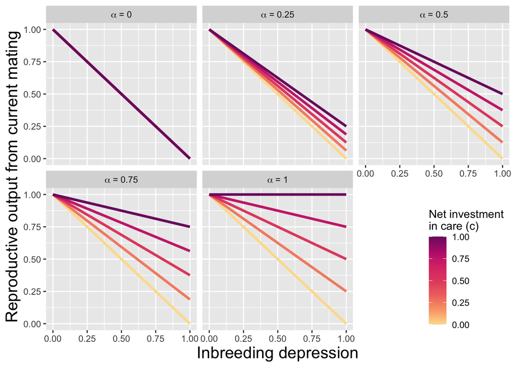

```r
expand_grid(D = seq(from = 0, to = 1, by = 0.05),
            c = seq(from = 0, to = 1, by = 0.25),
            a = seq(from = 0, to = 1, by = 0.25)) %>%
  mutate(fitness = 1 - D*(1-a*c) ) %>%
    mutate(a = case_when(a == 0 ~ "alpha*' = 0'",
                       a == 0.25 ~ "alpha*' = 0.25'",
                       a == 0.5 ~ "alpha*' = 0.5'",
                       a == 0.75 ~ "alpha*' = 0.75'",
                       a == 1 ~ "alpha*' = 1'")) %>%
  ggplot(aes(x = D, y = fitness, group = c, colour = c)) +
  geom_line(linewidth = 1.2) +
  scale_colour_carto_c(palette = "SunsetDark", type = "qualitative",
                       limits = c(0, 1)) +
  labs(y = "Reproductive output from current mating",
       x = "Inbreeding depression",
       colour = "Net investment\nin care (c)") +
  facet_wrap(~ factor(a, levels = c("alpha*' = 0'", "alpha*' = 0.25'",
                                        "alpha*' = 0.5'", "alpha*' = 0.75'",
                                        "alpha*' = 1'")), labeller = label_parsed) +
  theme(axis.title = element_text(size = 16),
        legend.position = c(1, 0),
        legend.justification = c(1, 0))
```

**Figure 1**. the effect of inbreeding depression on reproductive output when there is parental care.

**Note**

Click on the Figure to enlarge

Incorporating these into Equation 1 and Equation 2 I find

$$[1-\delta(1-\alpha c)] + (N_\mathrm{f} - \Delta N_\mathrm{f}) + r[1 - \delta(1-\alpha c) - \Delta N_\mathrm{m}] > N_\mathrm{f} \qquad \tag{4}$$

$$[1-\delta(1-\alpha c)] + (N_\mathrm{m} - \Delta N_\mathrm{m}) + r[1 - \delta(1-\alpha c) - \Delta N_\mathrm{f}] > N_\mathrm{m} \qquad \tag{5}$$

In turn, the $\delta_\mathrm{f}$ and $\delta_\mathrm{m}$ inequalities become:

$$\delta_\mathrm{f} < \frac{(1 -\Delta N_\mathrm{f}) + (r - r\Delta N_\mathrm{m})}{1 + r - \alpha c - r\alpha c} \tag{6}$$

$$\delta_\mathrm{m} < \frac{(1 -\Delta N_\mathrm{m}) + (r - r\Delta N_\mathrm{f})}{1 + r - \alpha c - r\alpha c} \tag{7}$$

Thus, for both sexes non-zero care (that has some mitigating effect on inbreeding depression) makes the denominator smaller, which increases the inbreeding depression threshold below which selection favours inbreeding.

To explore this, set $\Delta N_\mathrm{f} = 1$ and $\Delta N_\mathrm{m} = 0$, which describes a mating system where only females provide care. Recall that $c = (\Delta N_\mathrm{f} + \Delta N_\mathrm{m}) / 2$, which when substituted into Equation 6 and Equation 7 gives

$$\delta_\mathrm{f} < \frac{r}{1 + r - \frac{\alpha}{2} - \frac{r\alpha}{2}}$$

$$\delta_\mathrm{m} < \frac{1}{1 + r - \frac{\alpha}{2} - \frac{r\alpha}{2}}$$
We can plot these thresholds

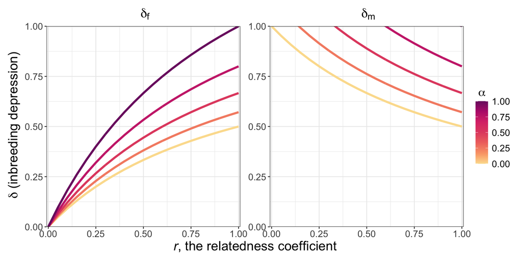

```r
# females

parameters_f <- expand_grid(r = seq(from = 0, to = 1, by = 0.05),
                          delta = seq(from = 0, to = 1, by = 0.05),
                          a = c(0, 0.25, 0.5, 0.75, 1)) %>%
  mutate(depression_threshold = r / (1 + r - 0.5*a - 0.5*r*a))

delta_f_plot <-
  parameters_f %>%
  ggplot(aes(x = r, y = depression_threshold, group = a, colour = a)) +
  geom_line(linewidth = 1.4) +
  coord_cartesian(ylim = c(0, 1)) +
  scale_colour_carto_c(palette = "SunsetDark", type = "qualitative",
                       limits = c(0, 1)) +
  labs(x = '_r_, the relatedness coefficient',
       y = ~delta~'(inbreeding depression)',
       title = ~ paste(delta [f]),
       colour = ~alpha~'') +
  #facet_wrap(~a) +
  scale_x_continuous(expand = c(0, 0.009)) +
  scale_y_continuous(expand = c(0, 0)) +
  theme_bw() +
  theme(text = element_text(size = 16),
        axis.title = element_text(size = 18),
        axis.title.x = element_markdown(),
        plot.title = element_text(size = 18, hjust = 0.5))

# males

parameters_m <- expand_grid(r = seq(from = 0, to = 1, by = 0.05),
                          delta = seq(from = 0, to = 1, by = 0.05),
                          a = c(0, 0.25, 0.5, 0.75, 1)) %>%
  mutate(depression_threshold = 1 / (1 + r - 0.5*a - 0.5*r*a))

delta_m_plot <-
  parameters_m %>%
  ggplot(aes(x = r, y = depression_threshold, group = a, colour = a)) +
  geom_line(linewidth = 1.4) +
  coord_cartesian(ylim = c(0, 1)) +
  scale_colour_carto_c(palette = "SunsetDark", type = "qualitative",
                       limits = c(0, 1)) +
  labs(x = '_r_, the relatedness coefficient',
       y = ~delta~'(inbreeding depression)',
       title = ~ paste(delta [m]),
       colour = ~alpha~'') +
  scale_x_continuous(expand = c(0, 0.009)) +
  scale_y_continuous(expand = c(0, 0)) +
  theme_bw() +
  theme(text = element_text(size = 16),
        axis.title = element_text(size = 18),
        axis.title.x = element_markdown(),
        plot.title = element_text(size = 18, hjust = 0.5))

delta_f_plot + delta_m_plot + plot_layout(guides = "collect", axis_titles = "collect")
```

**Figure 2**. Inbreeding tolerance thresholds when parental care is female-limited. Different coloured lines show thresholds for different levels of care effectiveness. The left panel shows the conditions required for selection to favour inbreeding in females, while the right shows these conditions for inbreeding in males.

The plot shows that as care more effectively buffers inbreeding depression, the conditions for selection to favour inbreeding become more permissive. As shown previously, relatedness between mating partners has opposite effects depending on the sex expressing the inbreeding allele. To show why, Equation 4 and Equation 5 can be rearranged in the form of Hamilton’s rule $rb > c$. Let $\alpha = 0$ (no effect of care - shown by the yellow line in the Figure), and as before, $\Delta N_\mathrm{f} = 1$ and $\Delta N_\mathrm{m} = 0$. For alleles expressed in females we find that selection favours inbreeding when

$$\underbrace{r(1 - \delta)}_\textrm{male benefit} > \underbrace{\delta}_\textrm{female cost}$$
where inbreeding is a form of altruism. For alleles expressed in males, the altruistic behaviour is to avoid inbreeding (thus sparing females a bout of inbred offspring). To aid interpretation, I flip the inequality to instead express the conditions for selection to favour males to behave selfishly and hence to increase the frequency of alleles that code for inbreeding

$$\underbrace{1 - \delta}_\textrm{male benefit} > \underbrace{r\delta}_\textrm{female cost}$$

Thus, relatedness expands the space where selection favours inbreeding for females, but reduces it for males. Increasing $r$ therefore reduces conflict between the sexes over inbreeding.

**Note**

When $\alpha = 1$, selection will favour males that inbreed in all cases where inbreeding depression < 1. Hence, the corresponding dark purple line never appears in Figure 2.

Now, what happens when males care? Insepction of Equation 6 and Equation 7 reveals two, opposing effects. Increasing $\Delta N_\mathrm{m}$ decreases the size of the *numerator*, or put biologically, reduces a male’s future reproductive success. However it also leads to an increase in $c$, mitigating the effect of inbreeding depression on offspring production/survival, thus decreasing the size of the *denominator*. Whether inbreeding is favoured when males invest more in care depends largely on the $\alpha$ parameter.

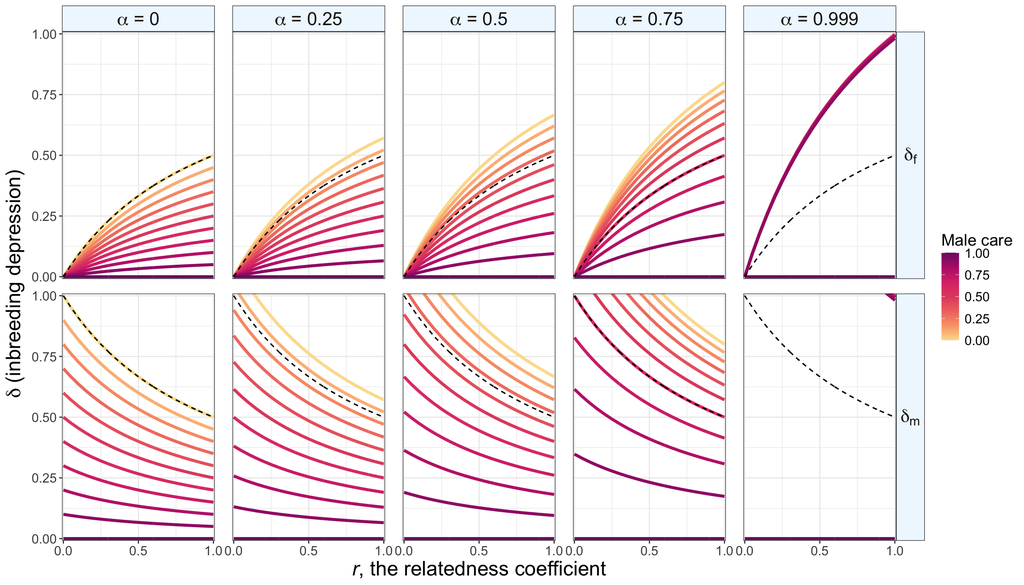

```r
# females

parameters_f_care <- expand_grid(r = seq(from = 0, to = 1, by = 0.05),
                          delta = seq(from = 0, to = 1, by = 0.05),
                          a = c(0, 0.25, 0.5, 0.75, 0.999),
                          N_m = seq(from = 0, to = 1, by = 0.1)) %>%
  mutate(depression_threshold = (r - r*N_m) / (1 + r - ((1+N_m)/2)*a - ((1+N_m)/2)*r*a),
         control_threshold = r / (1 + r),
         sex = "delta[f]")

# males

parameters_m_care <- expand_grid(r = seq(from = 0, to = 1, by = 0.05),
                          delta = seq(from = 0, to = 1, by = 0.05),
                          a = c(0, 0.25, 0.5, 0.75, 0.999),
                          N_m = seq(from = 0, to = 1, by = 0.1)) %>%
  mutate(depression_threshold = (1 - N_m) / (1 + r - ((1+N_m)/2)*a - ((1+N_m)/2)*r*a),
         control_threshold = 1 / (1 + r),
         sex = "delta[m]")

# combine

care_parameters <-
  bind_rows(parameters_f_care, parameters_m_care) %>%
  mutate(a = case_when(a == 0 ~ "alpha*' = 0'",
                       a == 0.25 ~ "alpha*' = 0.25'",
                       a == 0.5 ~ "alpha*' = 0.5'",
                       a == 0.75 ~ "alpha*' = 0.75'",
                       a == 0.999 ~ "alpha*' = 0.999'"))

# plot

delta_Nm_pc_plot <-
  care_parameters %>%
  ggplot(aes(x = r, y = depression_threshold, group = N_m, colour = N_m)) +
  geom_line(linewidth = 1.4) +
  geom_line(aes(y = control_threshold), linetype = 2, colour = "black") +
  coord_cartesian(ylim = c(0, 1)) +
  scale_colour_carto_c(palette = "SunsetDark", type = "qualitative",
                       limits = c(0, 1)) +
  labs(x = '_r_, the relatedness coefficient',
       y = ~delta~'(inbreeding depression)',
       colour = "Male care") +
  facet_grid(sex ~ factor(a, levels = c("alpha*' = 0'", "alpha*' = 0.25'",
                                        "alpha*' = 0.5'", "alpha*' = 0.75'",
                                        "alpha*' = 0.999'")), labeller = label_parsed) +
  scale_x_continuous(expand = c(0, 0.009), breaks = c(0, 0.5, 1)) +
  scale_y_continuous(expand = c(0, 0.009)) +
  theme_bw() +
  theme(text = element_text(size = 16),
        strip.text = element_text(size = 18),
        strip.text.y = element_text(angle = 0),
        strip.background = element_rect(fill = "aliceblue"),
        axis.title = element_text(size = 20),
        axis.title.x = element_markdown(),
        panel.spacing.x = unit(1.2, "lines"),
        panel.spacing.y = unit(1, "lines"))

delta_Nm_pc_plot
```

**Figure 3**. Inbreeding depression thresholds (before buffering) for varying values of relatedness, male investment in care and the ability of care to buffer inbreeding depression. The dashed line shows the inbreeding threshold when care does not affect inbreeding depression and reproductive investment is female-limited (hereafter referred to as the control condition). $\Delta N_\mathrm{f} = 1$ in all panels.

**Note**

The rightmost panels show an unusual result. When care is completely effective at buffering inbreeding depression ($\alpha = 1$), then all levels of male care investment where $\Delta N_\mathrm{m} < 1$ predict the same inbreeding depression threshold for a given relatedness coefficient. Intriguely the thresholds in this case are $\delta_\mathrm{f} < \frac{2r}{1 + r}$ and $\delta_\mathrm{f} < \frac{2}{1 + r}$; exactly twice the amount of inbreeding that can be tolerated when care has no effect. However, when males simply swap an outcrossing event for an inbred mating ($\Delta N_\mathrm{m} = 1$), inbreeding is selectively neutral. That is, inbreeding and outcrossing are no different, creating a one for one swap.

## How we can test this?

This depends on the pliability and specifics of the Burying beetle system. First, males must care to a lesser extent than females and inbreeding must increase lifetime mating success of males. If the degree of care provided by a male can be manipulated without much change in female care and this feeds back into future male mating prospects, then experimental evolution could be very cool. For example, if there is reasonably large heritability for inbreeding preference/avoidance, I would expect to see differences evolve in mating preferences between populations where males care a lot (inbreeding rare) and one’s with female-biased care (inbreeding common).

Other manipulations that could test predictions include:

- varying the effectiveness of care
- varying the severity of inbreeding depression